# Majoritarian elections · 🗳️

Author

Holger Döring

Published

July 13, 2024

```r
library(conflicted) # create errors for function name conflicts

library(tidyverse)
conflicts_prefer(dplyr::filter, .quiet = TRUE)
library(knitr) # layout // tables in RMarkdown with kable()

ggplot2::theme_set(theme_minimal())
options(scipen = 999) # suppress scientific notation

library(patchwork) # plots  // arrange
library(reactable) # layout // interactive data tables
```

## UK 2024 election

[figure not shown]

Photo by Kristina Gadeikyte on Unsplash

Majoritarian electoral systems convert votes into seats disproportionally and provide a seats bonus for the winning party. However, the votes-seats ratio of the Labour party in the 2024 election is rather high.

Here, I provide a brief overview of the votes-seats translation for majoritarian electoral systems (first-past-the-post and two-round) in democratic regimes, following the V-Dem classifications.

For some background on electoral systems around the world, see the notebooks about [types](https://hdigital.github.io/data-snippets/notebooks/2021_electoral-systems_types.nb.html) and [evolution](https://hdigital.github.io/data-snippets/notebooks/2021_electoral-systems_evolution.nb.html) of electoral systems since 1900.

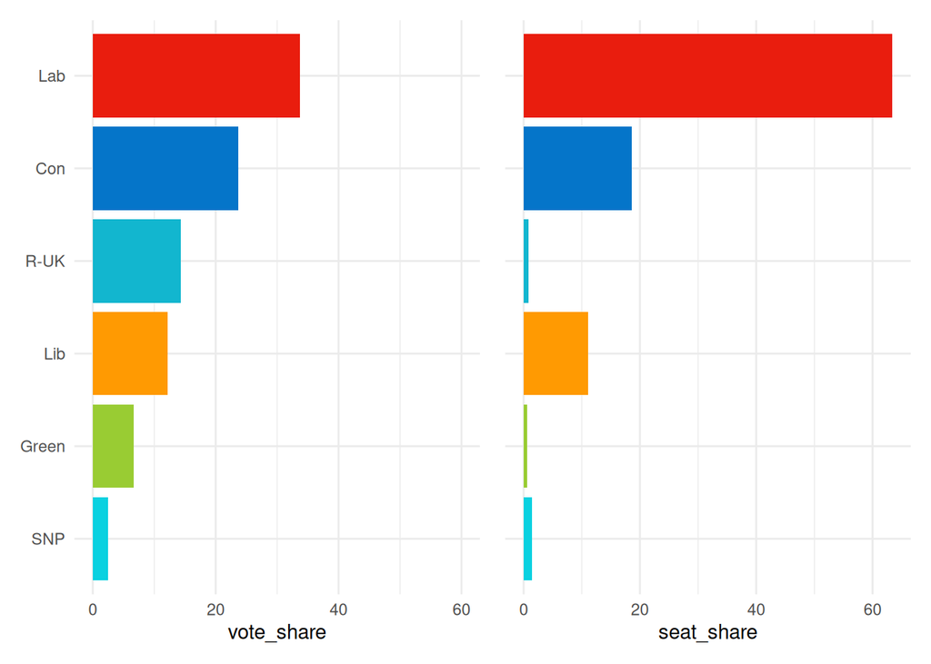

```r
elec_raw <- read_csv("data/uk-election-2024_bbc.csv")

pl_dt <-
  elec_raw |>
  mutate(
    seat_share = round(seats / 650 * 100, 1), # total seats UK Parliament: 650
    party = fct_reorder(party, vote_share)
  ) |>
  filter(vote_share >= 2.5)

party_colors <- c(
  "Lab" = "#E91D0E",
  "Con" = "#0575C9",
  "R-UK" = "#12b6cf",
  "Lib" = "#FF9A02",
  "Green" = "#99CC33",
  "SNP" = "#0AD1E0"
)

pl1 <-
  ggplot(pl_dt, aes(x = vote_share, y = party, fill = party)) +
  geom_col() +
  xlim(0, 60) +
  scale_fill_manual(values = party_colors) +
  labs(y = NULL) +
  theme(legend.position = "none")

pl2 <-
  ggplot(pl_dt, aes(x = seat_share, y = party, fill = party)) +
  geom_col() +
  scale_fill_manual(values = party_colors) +
  labs(y = NULL) +
  theme(axis.text.y = element_blank(), legend.position = "none")

pl1 + pl2
```

## V-Party data

Election results are from [V-Party](https://v-dem.net/data/v-party-dataset/) (v2) and electoral systems classifications from [V-Dem](https://v-dem.net/data/v-party-dataset/) (v11.1).

For the analysis, election results are selected for all majoritarian electoral systems (first-past-post and two round) in democratic regimes since 1900 (V-Dem classifications).

```r
callr::rscript("data-raw.R")
```

## UK elections

### Con · Lab · Lib

UK election results for Conservatives, Labour, and Liberals from 1900 to 2024 with 2024 results added from [BBC News](https://www.bbc.com/news/election/2024/uk/results).

```r
uk_3 <- read_csv("data/uk-elections_top-3_vparty.csv")
```

Seat and vote share of three main parties in the UK.

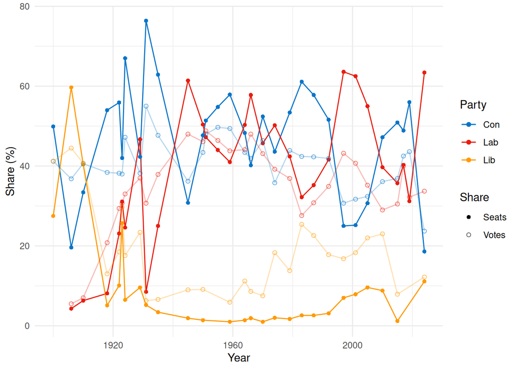

```r
pl <-
  ggplot(uk_3, aes(x = year, color = party)) +
  geom_line(aes(y = seat_share)) +
  geom_point(aes(y = seat_share, shape = "Seats")) +
  geom_line(aes(y = vote_share), alpha = 0.3) +
  geom_point(aes(y = vote_share, shape = "Votes"), alpha = 0.6) +
  labs(x = "Year", y = "Share (%)", color = "Party", shape = "Share") +
  scale_color_manual(values = party_colors) +
  scale_shape_manual(values = c("Seats" = 16, "Votes" = 1))

ggsave("figures/elections-uk.png", plot = pl, width = 10, height = 6, dpi = 300)
pl
```

### Votes-Seats differences

Two highest seat share **gains** through positive votes-seats ratio by party.

```r
uk_3 |>
  slice_max(order_by = share_diff, n = 2, by = c(party)) |>
  select(party, year, share_gain = share_diff, seat_share, vote_share) |>
  arrange(party, desc(share_gain))
```

| party | year | share_gain | seat_share | vote_share |
| --- | --- | --- | --- | --- |
| Con | 1931 | 21.4 | 76.4 | 55.0 |
| Con | 1924 | 19.8 | 67.0 | 47.2 |
| Lab | 2024 | 29.7 | 63.4 | 33.7 |
| Lab | 2001 | 21.8 | 62.5 | 40.7 |
| Lib | 1906 | 15.2 | 59.7 | 44.5 |
| Lib | 1910 | -0.3 | 40.4 | 40.7 |

Seat share **losses** through negative votes-seats ratio.

```r
uk_3 |>
  slice_min(order_by = share_diff, n = 2, by = c(party)) |>
  select(party, year, share_loss = share_diff, seat_share, vote_share) |>
  arrange(party, share_loss)
```

| party | year | share_loss | seat_share | vote_share |
| --- | --- | --- | --- | --- |
| Con | 1906 | -17.2 | 19.6 | 36.8 |
| Con | 1910 | -7.2 | 33.4 | 40.6 |
| Lab | 1931 | -22.2 | 8.5 | 30.7 |
| Lab | 1935 | -12.9 | 25.0 | 37.9 |
| Lib | 1983 | -22.8 | 2.6 | 25.4 |
| Lib | 1987 | -20.0 | 2.6 | 22.6 |

### Share changes

Two highest vote share **gains** compared to previous election and seat share change by party.

```r
uk_3 |>
  slice_max(order_by = vote_change, n = 2, by = c(party)) |>
  select(party, year, vote_change, vote_share, seats_change, seat_share)
```

| party | year | vote_change | vote_share | seats_change | seat_share |
| --- | --- | --- | --- | --- | --- |
| Con | 1931 | 16.8 | 55.0 | 34.1 | 76.4 |
| Con | 1924 | 9.2 | 47.2 | 25.0 | 67.0 |
| Lib | 1983 | 11.6 | 25.4 | 0.9 | 2.6 |
| Lib | 1923 | 11.2 | 29.7 | 15.6 | 25.7 |
| Lab | 1918 | 13.8 | 20.8 | 1.8 | 8.1 |
| Lab | 1945 | 10.1 | 48.0 | 36.4 | 61.4 |

Vote share **losses** and seat share change.

```r
uk_3 |>
  slice_min(order_by = vote_change, n = 2, by = c(party)) |>
  select(party, year, vote_change, vote_share, seats_change, seat_share)
```

| party | year | vote_change | vote_share | seats_change | seat_share |
| --- | --- | --- | --- | --- | --- |
| Con | 2024 | -19.9 | 23.7 | -37.4 | 18.6 |
| Con | 1945 | -11.5 | 36.2 | -32.1 | 30.8 |
| Lib | 1918 | -27.7 | 13.0 | -35.3 | 5.1 |
| Lib | 1931 | -17.1 | 6.3 | -4.4 | 5.2 |
| Lab | 1983 | -9.3 | 27.6 | -10.2 | 32.2 |
| Lab | 2019 | -7.8 | 32.2 | -9.1 | 31.2 |

## Majoritarian systems

### Nine countries

Votes-seats differences for the two largest parties in an election.

Nine countries with the highest number of majoritarian elections are presented.

```r
top_2 <- read_csv("data/majoritarian-elections_top-2_vparty.csv")
```

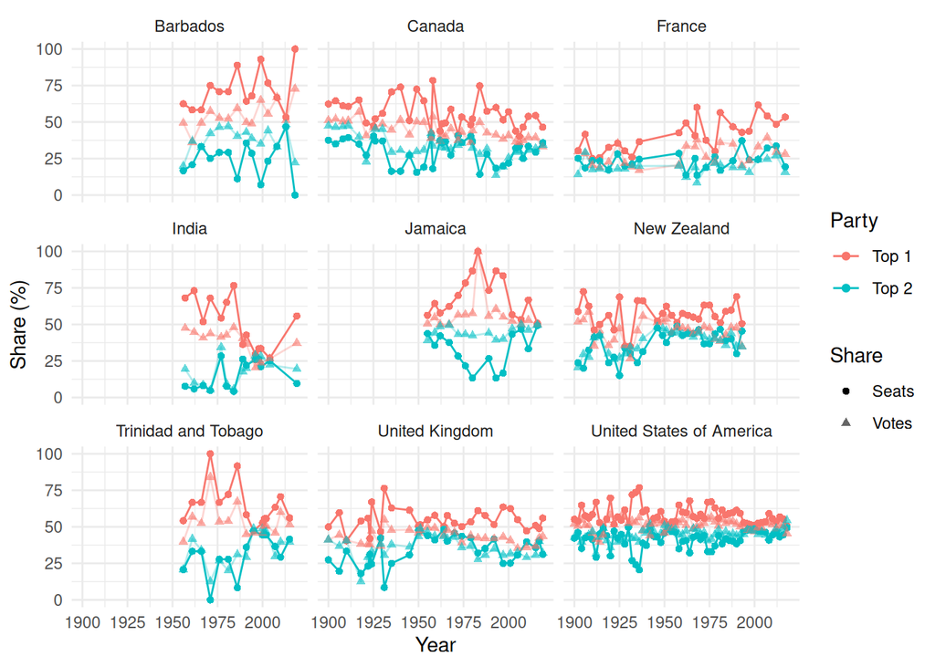

```r
ctry_count <-
  top_2 |>
  distinct(country, year) |>
  count(country, sort = TRUE)


pl <-
  top_2 |>
  filter(country %in% ctry_count[["country"]][1:9]) |>
  ggplot(aes(x = year, color = rank)) +
  geom_line(aes(y = seat_share)) +
  geom_point(aes(y = seat_share, shape = "Seats")) +
  geom_line(aes(y = vote_share), alpha = 0.3) +
  geom_point(aes(y = vote_share, shape = "Votes"), alpha = 0.6) +
  labs(x = "Year", y = "Share (%)", color = "Party", shape = "Share") +
  facet_wrap(vars(country_name))

ggsave("figures/elections-majoritarian.png",
  plot = pl, width = 10, height = 6, dpi = 300
)
pl
```

### Votes-seats

Votes and seats share differences in majoritarian democratic elections.

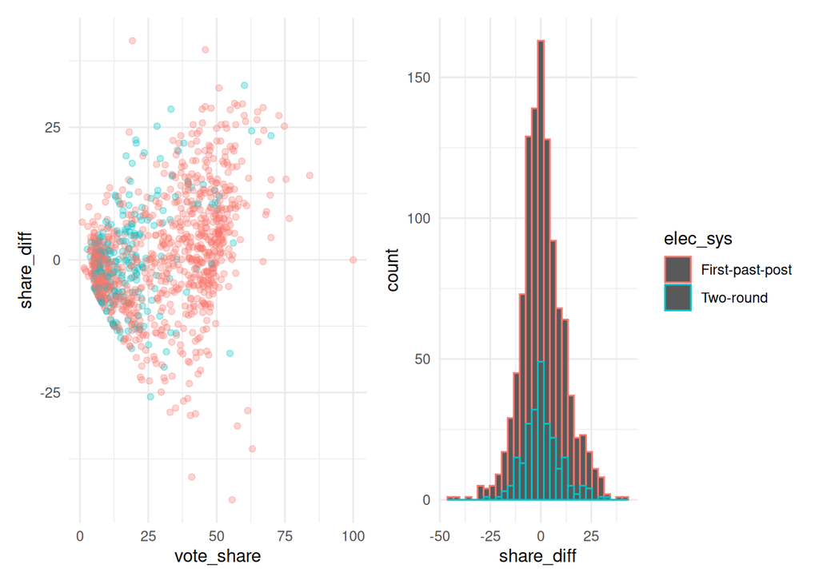

```r
vparty_elec <- read_csv("data/majoritarian-elections_vparty.csv")

pl1 <-
  ggplot(vparty_elec, aes(x = vote_share, y = share_diff, colour = elec_sys)) +
  geom_point(alpha = 0.3) +
  guides(colour = "none")

pl2 <-
  ggplot(vparty_elec, aes(x = share_diff, colour = elec_sys)) +
  geom_histogram()

pl1 + pl2 + plot_layout(widths = c(3, 2))
```

Highest vote/seat share difference for all democratic regimes with majoritarian elections.

```r
top_2 |>
  slice_max(order_by = share_diff, n = 1, by = c(country)) |>
  select(country, country_name, year, party, vote_share, seat_share, share_diff) |>
  arrange(desc(share_diff)) |>
  reactable(searchable = TRUE, striped = TRUE)
```

| country | country_name | year | party | vote_share | seat_share | share_diff |
| --- | --- | --- | --- | --- | --- | --- |
| SLB | Solomon Islands | 1989 | PAP | 19.2 | 60.5 | 41.3 |
| MNG | Mongolia | 2016 | MAN | 45.9 | 85.5 | 39.6 |
| SGP | Singapore | 2011 | PAP | 60.2 | 93.1 | 32.9 |
| LKA | Sri Lanka | 1977 | UNP | 50.9 | 83.3 | 32.4 |
| GMB | The Gambia | 1987 | PPP | 56.6 | 86.1 | 29.5 |
| BRB | Barbados | 1986 | DLP | 59.5 | 88.9 | 29.4 |
| JAM | Jamaica | 1980 | JLP | 57.6 | 86.7 | 29.1 |
| MDV | Maldives | 2019 | MDP | 45.8 | 74.7 | 28.9 |
| BTN | Bhutan | 2008 | DPT | 67 | 95.7 | 28.7 |
| IND | India | 1984 | INC | 48 | 76.6 | 28.6 |

[output cut: 34 more lines]

### Electoral systems

[Types of electoral systems](https://hdigital.github.io/data-snippets/notebooks/2021_electoral-systems_types.nb.html) in democratic regimes classified by [Bormann and Golder (2013)](https://doi.org/10.1016/j.electstud.2013.01.005).

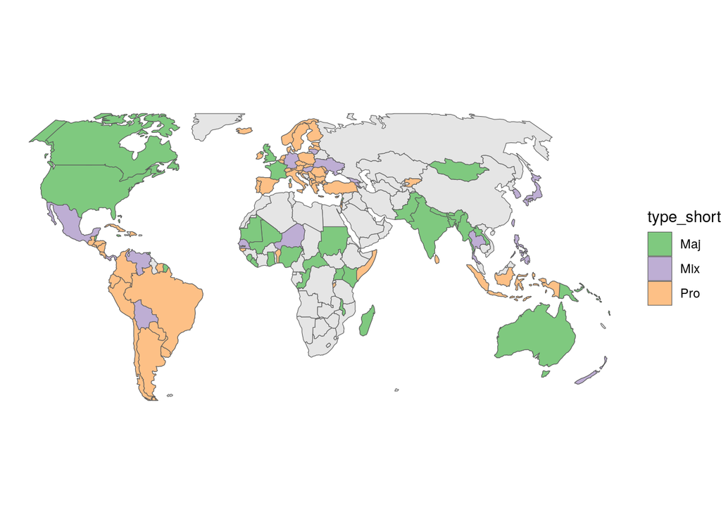

## Explore data

### UK · Con, Lab, Lib

```r
uk_3 |>
  select(year:seats_total) |>
  reactable(searchable = TRUE, striped = TRUE)
```

| year | party | vote_share | seat_share | share_diff | seats | seats_total |
| --- | --- | --- | --- | --- | --- | --- |
| 1900 | Con | 41.2 | 49.9 | 8.7 | 334 | 670 |
| 1900 | Lib | 41.2 | 27.5 | -13.7 | 184 | 670 |
| 1906 | Con | 36.8 | 19.6 | -17.2 | 131 | 670 |
| 1906 | Lab | 5.5 | 4.3 | -1.2 | 29 | 670 |
| 1906 | Lib | 44.5 | 59.7 | 15.2 | 400 | 670 |
| 1910 | Con | 40.6 | 33.4 | -7.2 | 224 | 670 |
| 1910 | Lab | 7 | 6.3 | -0.7 | 42 | 670 |
| 1910 | Lib | 40.7 | 40.4 | -0.3 | 271 | 670 |
| 1918 | Con | 38.4 | 54 | 15.6 | 382 | 707 |
| 1918 | Lab | 20.8 | 8.1 | -12.7 | 57 | 707 |

[output cut: 78 more lines]

### Top 2 · Majoritarian

```r
top_2 |>
  select(country, country_name, year, party, vote_share, seat_share, share_diff) |>
  reactable(searchable = TRUE, striped = TRUE)
```

| country | country_name | year | party | vote_share | seat_share | share_diff |
| --- | --- | --- | --- | --- | --- | --- |
| AUS | Australia | 1903 | PP | 29.7 | 34.7 | 5 |
| AUS | Australia | 1903 | FTP | 34.4 | 33.3 | -1.1 |
| AUS | Australia | 1906 | FTP | 38.2 | 36 | -2.2 |
| AUS | Australia | 1906 | ALP | 36.6 | 34.7 | -1.9 |
| AUS | Australia | 1910 | ALP | 50 | 57.3 | 7.3 |
| AUS | Australia | 1910 | CLP | 45.1 | 41.3 | -3.8 |
| AUS | Australia | 1913 | CLP | 48.9 | 50.7 | 1.8 |
| AUS | Australia | 1913 | ALP | 48.5 | 49.3 | 0.8 |
| AUS | Australia | 1914 | ALP | 50.9 | 56 | 5.1 |
| AUS | Australia | 1914 | CLP | 47.2 | 42.7 | -4.5 |

[output cut: 666 more lines]

**Electoral systems**

```r
top_2 |>
  distinct(country, country_name, elec_sys) |>
  reactable(searchable = TRUE, striped = TRUE)
```

| country | country_name | elec_sys |
| --- | --- | --- |
| AUS | Australia | First-past-post |
| BGD | Bangladesh | First-past-post |
| BRB | Barbados | First-past-post |
| BTN | Bhutan | First-past-post |
| BWA | Botswana | First-past-post |
| CAN | Canada | First-past-post |
| CHE | Switzerland | Two-round |
| CIV | Ivory Coast | First-past-post |
| COM | Comoros | Two-round |
| DNK | Denmark | First-past-post |

[output cut: 35 more lines]

## References

```r
library(httr2)

get_doi_reference <- function(doi) {
  request(paste0("https://doi.org/", doi)) |>
    req_headers("Accept" = "text/x-bibliography") |>
    req_perform() |>
    resp_body_string()
}

references_doi <- c(
  "10.1016/j.electstud.2013.01.005",
  "10.2139/ssrn.3831905",
  "10.1080/13569775.2021.1993564",
  "10.23696/vpartydsv2"
)

references <- map_chr(references_doi, get_doi_reference)
```

- Bormann, N.-C., & Golder, M. (2013). Democratic Electoral Systems around the world, 1946–2011. Electoral Studies, 32(2), 360–369. https://doi.org/10.1016/j.electstud.2013.01.005
- Coppedge, M., Gerring, J., Knutsen, C. H., Lindberg, S. I., Teorell, J., Alizada, N., Altman, D., Bernhard, M., Cornell, A., Fish, M. S., Gastaldi, L., Gjerløw, H., Glynn, A., Hicken, A., Hindle, G., Ilchenko, N., Krusell, J., Lührmann, A., Maerz, S. F., … Ziblatt, D. (2021). V-Dem Dataset v11.1. SSRN Electronic Journal. https://doi.org/10.2139/ssrn.3831905
- Kasuya, Y., & Mori, K. (2021). Re-examining thresholds of continuous democracy measures. Contemporary Politics, 28(4), 365–385. https://doi.org/10.1080/13569775.2021.1993564
- Staffan. I. Lindberg, Nils Düpont, Masaaki Higashijima, Yaman Berker Kavasoglu, Kyle L. Marquardt, Michael Bernhard, Holger Döring, Allen Hicken, Melis Laebens, Juraj Medzihorsky, Anja Neundorf, Ora John Reuter, Saskia Ruth-Lovell, Keith R. Weghorst, Nina Wiesehomeier, Joseph Wright, Nazifa Alizada, Paul Bederke, Lisa Gastaldi, Sandra Grahn, Garry Hindle, Nina Ilchenko, Johannes Von Römer, Steven Wilson, Daniel Pemstein, Brigitte Seim. (2022). *V-Party Dataset v2* [Data set]. V-Dem Institute. https://doi.org/10.23696/VPARTYDSV2